# 第 7 章 神经网络

神经网络（NN）是一个内容极为丰富且复杂的主题。本章介绍最基本神经网络架构背后的核心思想与概念。若要深入了解神经网络的各种特性，可参阅 Haykin（2009）、Du 和 Swamy（2013）以及 Goodfellow 等人（2016）的专著；最后一本可在 www.deeplearningbook.org 免费在线阅读。若希望从实践入门，推荐 Chollet（2017）。

首先简要谈谈“神经网络”这一称谓。多数专家都认为这个名称并不十分恰当，因为神经网络与人脑的实际工作方式关系不大，而我们对后者本身也所知有限。这也解释了为什么它们常被称为“人工神经网络”；为简化记号，本文省略“人工”二字。François Chollet 给出的定义或许更为贴切：*“由可微、参数化的几何函数串联而成，并通过梯度下降训练，其中梯度由链式法则求得。”*

金融领域较早使用神经网络的研究包括 Bansal 和 Viswanathan（1993），以及 Eakins、Stansell 和 Buck（1998），但两者目标截然不同。前者试图估计定价核的**非线性形式**；后者则识别并量化机构持股与公司属性之间的关系，可视为因子投资的早期贡献。Burrell 和 Folarin（1997）的早期综述列举了 20 世纪 90 年代神经网络在金融中的应用。较近的 Sezer、Gudelek 和 Ozbayoglu（2019）、Jiang（2020）以及 Lim 和 Zohren（2020），则回顾了以计算机科学研究者为主、使用深度学习模型预测金融时间序列的工作。

神经网络在金融市场中的预测能力一直是热门主题。相关研究还包括 Kimoto 等人（1990）、Enke 和 Thawornwong（2005）、Zhang 和 Wu（2009）、Guresen、Kayakutlu 和 Daim（2011）、Krauss、Do 和 Huck（2017）、Fischer 和 Krauss（2018）、Aldridge 和 Avellaneda（2019）、Babiak 和 Barunik（2020）、Y. Ma、Han 和 Wang（2020），以及 Soleymani 和 Paquet（2020）。17 最后一项研究甚至把多种神经网络嵌入一个整体强化学习框架。这份列表远未穷尽。金融经济学中较新的神经网络研究还包括：

- Feng、Polson 和 Xu（2019）使用神经网络寻找最能解释股票横截面收益率的因子。
- Gu、Kelly 和 Xiu（2020b）把公司属性和宏观经济变量映射到未来收益率，从而构建出预测能力很强的模型。
- Luyang Chen、Pelger 和 Zhu（2020）使用包含生成对抗网络的复杂架构估计定价核，由此揭示预期股票收益率的结构，并通过构造最大夏普比率策略将其用于投资组合构建。

## 7.1 原始感知机

神经网络的起源至少可以追溯到 Rosenblatt（1958），当时的目标是二元分类。为简单起见，假设输出为 $\{0$ = 不投资 $\}$ 或 $\{1$= 投资 $\}$，例如分别对应负收益率和正收益率。用今天的术语说，感知机就是在线性映射之后应用激活函数。模型如下：

\begin{equation} f(\mathbf{x})=\left\{ \begin{array}{lll} 1 & \text{if } \mathbf{x}'\mathbf{w}+b >0\\ 0 &\text{otherwise} \end{array}\right. \end{equation}

权重向量 $\mathbf{w}$ 对各变量进行缩放，偏置 $b$ 则平移决策边界。给定 $b$ 和 $w_i$，误差为 $\epsilon_i=y_i-1_{\left\{\sum_{j=1}^Jx_{i,j}w_j+w_0>0\right\}}$。通常令 $b=w_0$，并在 $x$ 中加入常数列 $x_{i,0}=1$，于是 $\epsilon_i=y_i-1_{\left\{\sum_{j=0}^Jx_{i,j}w_j>0\right\}}$。与线性回归不同，感知机没有闭式解，只能近似求得最优权重。与回归类似，一种求取合适权重的方法是最小化误差平方和。最简单的更新过程是：

1. 计算样本 $\textbf{x}_i$ 当前的模型输出：$\tilde{y}_i=1_{\left\{\sum_{j=0}^Jw_jx_{i,j}>0\right\}}$；
2. 更新权重向量：$w_j \leftarrow w_j + \eta (y_i-\tilde{y}_i)x_{i,j}$。

这相当于沿相应方向移动权重。与树模型一样，缩放因子 $\eta$ 是学习率。较大的 $\eta$ 会带来更大的更新步长：模型学习得快，但可能收敛缓慢，甚至无法收敛。通常更倾向于较小的 $\eta$，因为它有助于降低过拟合风险。

图 7.1 展示了这一机制。初始模型用 7 个点训练，其中 3 个红点、4 个蓝点；随后出现一个新的黑点。

[figure not shown]

图 7.1：感知机示意图。

- 如果该点实际为红色，就无需调整，因为它位于决策边界右侧，已被正确分类。
- 如果该点实际为蓝色，就需要更新模型。按照上述规则，应向下调整直线斜率；调整幅度取决于 $\eta$，因此未必足以改变新点的分类结果。

感知机问世时被视为重大突破，也获得了媒体广泛报道，参见 Olazaran（1996）以及 Anderson 和 Rosenfeld（2000）。此后，这一简单结构逐步扩展为多个感知机组成的网络：每个感知机是一个基本单元，多个单元再组织成层。下一节介绍简单多层感知机 (MLP) 的结构。

## 7.2 多层感知机

### 7.2.1 简介与记号

感知机可以看作一个线性模型，再对其输出应用特定函数，即 Heaviside 阶跃函数。当然也可以选择其他函数；在神经网络术语中，这些函数称为激活函数，用于给原本线性的模型引入非线性。

正如随机森林组合多棵树一样，神经网络把许多类似感知机的基本模块组合起来。图 7.2 是神经网络的常见示意图，但它有所简化：每个绿色圆圈实际上都包含一个感知机，其输出先经过激活函数，再传给最终输出端进行聚合。这类模型因此称为多层感知机（MLP）。

[figure not shown]

图 7.2：多层感知机的简化示意图。

图 7.3 更准确地展示了网络内部的计算过程。

[figure not shown]

图 7.3：包含 2 个隐藏层的多层感知机详细示意图。

继续之前，先介绍本章使用的记号。

- 数据分为特征矩阵 $\textbf{X}=x_{i,j}$ 和输出值向量 $\textbf{y}=y_i$；$\textbf{x}$ 或 $\textbf{x}_i$ 表示 $\textbf{X}$ 的一行。
- 神经网络共有 $L\ge1$ 层，第 $l$ 层的单元数为 $U_l\ge1$。
- 第 $l$ 层第 $k$ 个单元的权重记为 $\textbf{w}_{k}^{(l)}=w_{k,j}^{(l)}$，相应偏置记为 $b_{k}^{(l)}$。$\textbf{w}_{k}^{(l)}$ 的长度等于 $U_{l-1}$。其中，$k$ 表示该单元在第 $l$ 层的位置，$j$ 表示与之相连的单元在第 $l-1$ 层的位置。
- 激活后的输出记为 $o_{i,k}^{(l)}$，其中 $i$ 表示样本，$l$ 表示层，$k$ 表示单元。

计算过程如下。数据进入网络后，首先经过线性映射：

\begin{equation} v_{i,k}^{(1)}=\textbf{x}_i'\textbf{w}^{(1)}_k+b_k^{(1)}, \text{for } l=1, \quad k \in [1,U_1], \end{equation}

随后用非线性函数 $f^{1}$ 对结果进行变换，并把变换后的值作为下一层输入。网络各层都会以不同权重重复这一线性映射：

\begin{equation} v_{i,k}^{(l)}=(\textbf{o}^{(l-1)}_i)'\textbf{w}^{(l)}_k+b_k^{(l)}, \text{for } l \ge 2, \quad k \in [1,U_l]. \end{equation}

层与层之间传递的是各单元的输出，也就是对线性映射应用激活函数 $f^{(l)}$ 后的结果。第 $l$ 层的输出构成第 $l+1$ 层的输入。

\begin{equation} o_{i,k}^{(l)}=f^{(l)}\left(v_{i,k}^{(l)}\right). \end{equation}

最后，输出层汇总最后一个隐藏层的输出：

\begin{equation} \tilde{y}_i =f^{(L+1)} \left((\textbf{o}^{(L)}_i)'\textbf{w}^{(L+1)}+b^{(L+1)}\right). \end{equation}

在输入数据的前向传播过程中，激活函数发挥着关键作用。图 7.4 绘出了神经网络软件包中最常用的激活函数。

[figure not shown]

图 7.4：常见激活函数。

从因子投资的角度看，输入 $\textbf{x}$ 就是公司的各项特征。第一步对这些特征加权求和并加入偏置，而且第一层的每个单元都会进行这项计算。所得线性组合再经过激活函数变换。每个单元输出一个值，这些值一同传入第二层，并按相同方式逐层计算，直至网络末端。输出层需要与标签的形式匹配：若标签为数值，输出是一个数；若标签为类别，输出通常是长度等于类别数的向量，向量中的各项表示样本属于相应类别的概率。

输出层也可以使用激活函数，而它的选择会显著影响结果。例如，若标签是收益率，在最后使用 sigmoid 函数就很不合适，因为 sigmoid 的输出始终为正，无法表示负收益率。

### 7.2.2 通用逼近

神经网络表现良好的一个原因，是它们具有通用逼近能力。对于任意有界连续函数，都存在一个单隐藏层网络，能够以任意精度逼近该函数。早期文献可参见 Cybenko（1989）；更完整的文献列表见 Du 和 Swamy（2013）第 4.2 节及 Goodfellow 等人（2016）第 6.4.1 节；较新的结果见 Guliyev 和 Ismailov（2018）。

形式上，单层感知机可写为

\begin{equation} f_n(\textbf{x})=\sum_{l=1}^nc_l\phi(\textbf{x}\textbf{w}_l+\textbf{b}_l)+c_0, \end{equation}

其中 $\phi$ 是非常数的有界连续函数。对于任意 $\epsilon>0$，都可以找到某个 $n$，使单位超立方体 $[0,1]^d$ 上的任意连续函数 $f$ 满足

\begin{equation} |f(\textbf{x})-f_n(\textbf{x})|< \epsilon, \quad \forall \textbf{x} \in [0,1]^d. \end{equation}

这一结果相当直观：只要在层中增加单元，就能提高逼近精度。它与多项式逼近颇为相似，不过具体性质还取决于激活函数是否有界、是否平滑、是否凸等。关于该主题的综述，可参见 Costarelli、Spigler 和 Vinti（2016）。

最初的通用逼近结果说明，只要允许使用任意多的单元，简单神经网络就能充分逼近任何性质良好的函数 $f$。但这些结果并不直接涉及学习阶段，也就是针对特定数据集优化模型的过程。Barron 在一系列论文中，尤其是 Barron（1993、1994），更精确地刻画了神经网络的能力。例如，Barron（1993）给出了通用逼近定理的一个定量版本：对某类使用 sigmoid 激活函数的网络，有 $\mathbb{E}[(f(\textbf{x})-f_n(\textbf{x}))^2]\le c_f/n$，从而把收敛速度与网络规模联系起来。该期望中的随机变量是 $x$，对应于数据被视为从某个固定分布独立同分布抽取的样本；这是机器学习中最常见的假设。

下面给出 Barron（1994）中的一个重要且易于解释的结果。

下文中，$f_n$ 表示一个可能带有惩罚项的神经网络，它只有一个包含 $n$ 个单元、使用 sigmoid 激活函数的隐藏层。另假设预测变量和标签的取值范围都有界，这并不是很强的限制。回归任务最重要的指标是均方误差 (MSE)，而主要结果给出了其数量级上界。设从 $N$ 个独立同分布抽取的样本点训练 $f_n$，且样本满足 $y_i=f(x_i)+\epsilon_i$，则可能达到的最优经验 MSE 具有如下数量级：

\begin{equation} \tag{7.1} \mathbb{E}\left[(f(x)-f_n(x))^2 \right]=\underbrace{O\left(\frac{c_f}{n} \right)}_{\text{size of network}}+\ \underbrace{O\left(\frac{nK \log(N)}{N} \right)}_{\text{size of sample}}, \end{equation}

其中 $K$ 是输入维度（列数），$c_f$ 是取决于数据生成函数 $f$ 的常数。上式给出了数据集规模为 $N$ 时，最优神经网络可达到误差的上界。

这个误差上界由两部分构成。第一部分取决于网络复杂度：与通用逼近定理一致，单元越多，逼近误差越小。但这并非全部。样本量同样决定了从独立同分布观测中学习的质量。第二部分随观测数按 $\log(N)/N$ 的速度下降，并与单元数和输入维度成正比。这清楚体现了样本规模与模型复杂度之间的权衡：样本很小时，过于复杂的模型没有意义；反过来，模型过于简单，也无法捕捉大型数据集中的细微关系。

总体而言，神经网络可以是参数众多、结构复杂的函数。在线性回归中，盲目加入解释变量可以机械地提高样本内拟合度；在神经网络中，只需随意增加各层单元，就能增加参数并取得类似效果。这显然不可取，因为高维网络很容易主要捕捉训练样本的特殊性，而非可推广的规律。

### 7.2.3 通过反向传播学习

与树模型类似，神经网络通过最小化带有惩罚项的损失函数来训练：

\begin{equation} O=\sum_{i=1}^I \text{loss}(y_i,\tilde{y}_i)+ \text{penalization}, \end{equation}

其中，$\tilde{y}_i$ 是模型预测值，$y_i$ 是样本真实值。为了便于计算，通常要求损失函数可微。回归任务最常用平方误差，分类任务最常用交叉熵。下一小节将讨论分类任务的技术细节。

训练神经网络，就是调整所有层、所有单元的权重与偏置，使上面定义的 $O$ 尽可能小。为简化记号，并注意到 $y_i$ 固定不变，记 $D(\tilde{y}_i(\textbf{W}))=\text{loss}(y_i,\tilde{y}_i)$，其中 $\textbf{W}$ 表示网络中的全部权重和偏置。参数通过梯度下降更新，即

\begin{equation} \tag{7.2} \textbf{W} \leftarrow \textbf{W}-\eta \frac{\partial D(\tilde{y}_i) }{\partial \textbf{W}}. \end{equation}

这是优化领域最经典的机制之一，图 7.5 给出了示意。图中突出说明了学习率过大可能带来的问题：较大的 $\eta$ 会使迭代在最优点附近来回振荡，而较小的学习率则更直接地收敛。

上式真正困难的是计算梯度，也就是确定参数应沿哪个方向调整。由于网络包含多层嵌套计算及相应激活函数，求导时必须反复应用链式法则。

[figure not shown]

图 7.5：梯度下降示意图。

近似导数最常见的方法之一是有限差分法。在损失函数二阶可微等常规条件下，中心差分满足：

\begin{equation} \frac{\partial D(\tilde{y}_i(w_k))}{\partial w_k} = \frac{D(\tilde{y}_i(w_k+h))-D(\tilde{y}_i(w_k-h))}{2h}+O(h^2), \end{equation}

其中 $h>0$ 是任意小的正数。该方法看似简单，计算成本却很高，因为所需运算次数与权重数量处于同一数量级。

幸运的是，可以利用一个技巧大幅简化并加速计算：沿链式法则逐层求导，同时复用已经计算过的中间项。先回顾

$\tilde{y}_i =f^{(L+1)} \left((\textbf{o}^{(L)}_i)'\textbf{w}^{(L+1)}+b^{(L+1)}\right)=f^{(L+1)}\left(b^{(L+1)}+\sum_{k=1}^{U_L} w^{(L+1)}_ko^{(L)}_{i,k} \right),$

因此，先对最靠近输出端的权重和偏置求导，得到：

\begin{align} \frac{\partial D(\tilde{y}_i)}{\partial w_k^{(L+1)}}&=D'(\tilde{y}_i) \left(f^{(L+1)} \right)'\left( b^{(L+1)}+\sum_{k=1}^{U_L} w^{(L+1)}_ko^{(L)}_{i,k} \right)o^{(L)}_{i,k} \\ \tag{7.3} &= D'(\tilde{y}_i) \left(f^{(L+1)} \right)'\left( v^{(L+1)}_{i,k} \right)o^{(L)}_{i,k} \\ \frac{\partial D(\tilde{y}_i)}{\partial b^{(L+1)}}&=D'(\tilde{y}_i) \left(f^{(L+1)} \right)'\left( b^{(L+1)}+\sum_{k=1}^{U_L} w^{(L+1)}_ko^{(L)}_{i,k} \right). \end{align}

这是最简单的一步。接下来要向前回到第 $L$ 层，这需要应用链式法则。利用恒等式 $v_{i,k}^{(L)}=(\textbf{o}^{(L-1)}_i)'\textbf{w}^{(L)}_k+b_k^{(L)}=b_k^{(L)}+\sum_{j=1}^{U_L}o^{(L-1)}_{i,j}w^{(L)}_{k,j}$，可继续写出：

\begin{align} \frac{\partial D(\tilde{y}_i)}{\partial w_{k,j}^{(L)}}&=\frac{\partial D(\tilde{y}_i)}{\partial v^{(L)}_{i,k}}\frac{\partial v^{(L)}_{i,k}}{\partial w_{k,j}^{(L)}} = \frac{\partial D(\tilde{y}_i)}{\partial v^{(L)}_{i,k}}o^{(L-1)}_{i,j}\\ &=\frac{\partial D(\tilde{y}_i)}{\partial o^{(L)}_{i,k}} \frac{\partial o^{(L)}_{i,k} }{\partial v^{(L)}_{i,k}} o^{(L-1)}_{i,j} = \frac{\partial D(\tilde{y}_i)}{\partial o^{(L)}_{i,k}} (f^{(L)})'(v_{i,k}^{(L)}) o^{(lL1)}_{i,j} \\ &=\underbrace{D'(\tilde{y}_i) \left(f^{(L+1)} \right)'\left(v^{(L+1)}_{i,k} \right)}_{\text{computed above!}} w^{(L+1)}_k (f^{(L)})'(v_{i,k}^{(L)}) o^{(L-1)}_{i,j}, \end{align}

如最后一行所示，导数的一部分已在上一步，也就是方程（7.3）中算出。因此可以复用该数值，只需计算表达式中尚未得到的部分。

反向传播的关键在于，上述复用可以贯穿求导的每一步。计算第 $l$ 层权重和偏置的梯度时，总能分成两部分：一部分由后续层反向传回，可以直接复用；另一部分是局部项，只取决于当前层的数值和激活函数。Google 开发团队在 playground.tensorflow.org 提供了直观演示。

当数据以张量形式组织时，还可以使用向量化，把运算调用次数控制在与网络节点（单元）数相当的数量级。

反向传播算法可概括如下。给定一批样本点，批次也可以只有一个样本：

1. 数据从左向右流动，如图 7.6 的蓝色箭头所示，这一步称为**前向传播**；
2. 根据前向传播的输出计算误差或损失函数；
3. 从最后一层开始，向左逐层计算损失函数对权重和偏置的导数；图中的绿色箭头表示这一**反向传播**过程；
4. 利用所得梯度更新全部权重和偏置，使模型降低这批样本产生的损失或误差。

[figure not shown]

图 7.6：反向传播示意图。

上述过程可以使用不同批量大小重复任意多次。第 7.3 节将进一步讨论这一问题。

学习率 $\eta$ 还可以进一步调整。降低过拟合风险的一种做法，是在每个训练轮次后减小更新幅度。例如可设 $\eta=\alpha e^{- \beta t}$，其中 $t$ 表示训练轮次（epoch），$\alpha,\beta>0$。另一种更复杂的方法是引入动量，该思想源自 Polyak（1964）：

\begin{align} \tag{7.4} \textbf{W}_{t+1} & \leftarrow \textbf{W}_{t} - \textbf{m}_t \quad \text{with} \nonumber \\ \textbf{m}_t & \leftarrow \eta \frac{\partial D(\tilde{y}_i)}{\partial \textbf{W}_{t}}+\gamma \textbf{m}_{t-1}, \end{align}

其中，$t$ 是权重更新的序号。动量法通过加入记录上一次调整的记忆项 $\textbf{m}_{t-1}$，让当前更新继续沿相近方向前进，从而加快收敛。参数 $\gamma$ 通常取 0.9。

此后又逐步发展出更复杂的改进方法：

- Nesterov（1983）通过预估参数下一步的位置改进动量项；
- Adagrad（Duchi、Hazan 和 Singer（2011））对每个参数使用不同的学习率；
- Adadelta（Zeiler（2012））和 Adam（Kingma 和 Ba（2014））结合了 Adagrad 与动量法的思想。

最后，在某些极端情况下，梯度可能爆炸，把权重推离最优值。为避免这种现象，机器学习软件包通常提供梯度裁剪。用户以范数等形式指定梯度允许的最大幅度；一旦梯度超过阈值，就按比例缩放到该阈值。这样既保持梯度方向不变，又减小更新幅度。

### 7.2.4 分类问题的进一步说明

决策树的目标是构造同质子群，上一章已经介绍其实现过程。神经网络则不同，它直接最小化预测值 $\tilde{\textbf{y}}_i$ 与目标标签 $\textbf{y}_i$ 之间的误差。这里的 $\textbf{y}_i$ 仍是独热编码向量：除表示样本所属类别的一个分量为 1 外，其余分量均为 0。

处理分类问题的关键，是在网络输出端使用合适的激活函数。输出维度应等于待预测类别数 $J$。为简化记号，将激活前的输出写为 $\textbf{x}_i$，最常用的激活函数就是 softmax：

\begin{equation} \tilde{\textbf{y}}_i=s(\textbf{x})_i=\frac{e^{x_i}}{\sum_{j=1}^Je^{x_j}}.$ \end{equation}

选择 softmax 的理由很直接：它可以接受任意实数输入，并把有限维输出转换成各分量之和为 1 的向量。与树模型类似，这可以解释为类别上的“概率”向量。相应损失通常采用树模型中熵的推广形式。给定目标标签 $\textbf{y}_i=(y_{i,1},\dots,y_{i,L})=(0,0,\dots,0,1,0,\dots,0)$ 和预测输出 $\tilde{\textbf{y}}_i=(\tilde{y}_{i,1},\dots,\tilde{y}_{i,L})$，交叉熵定义为

\begin{equation} \tag{7.5} \text{CE}(\textbf{y}_i,\tilde{\textbf{y}}_i)=-\sum_{j=1}^J\log(\tilde{y}_{i,j})y_{i,j}. \end{equation}

交叉熵衡量两个向量之间的不一致程度。由于目标标签只有正确类别对应的分量非零，损失化简为 $-\log(\tilde{y}_{i,l})$，其余类别对应项均为零。当 $\tilde{y}_{i,l}=1$ 时，损失达到最小值，正好对应 $y_{i,l}=\tilde{y}_{i,l}$。实际应用中很难恰好达到这一理想状态；预测概率 $\tilde{y}_{i,l}$ 越低，损失就越大。

### 7.3 网络应有多深及其他实践问题

构建神经网络时，除前几节已经介绍的选择外，还有许多超参数需要决定。下面概述网络构造与训练中的几项常见选择。

### 7.3.1 架构选择

第一类选择涉及网络结构。除前馈网络与循环网络之分外（见第 7.5 节），最直接的问题是网络应当多宽、多深。先计算网络中需要估计或优化的参数总数，即权重与偏置之和。

- 第一层共有 $(U_0+1)U_1$ 个参数，其中 $U_0$ 是 $\mathbb{X}$ 的列数，即解释变量数，  
  $U_1$ 是该层的单元数。
- 对于第 $l\in[2,L]$ 层，参数数目为 $(U_{l-1}+1)U_l$。
- 最终输出层共有 $U_L+1$ 个参数。
- 因此，需要优化的参数总数为

\begin{equation} \mathcal{N}=\left(\sum_{l=1}^L(U_{l-1}+1)U_l\right)+U_L+1 \end{equation}

与其他模型一样，参数数目应远小于样本数。虽然没有固定比例，但样本量最好至少是参数数目的 10 倍；若该比例低于 5，过拟合风险会很高。考虑到通常可获得的数据量，除非网络非常庞大，这一限制很少成为主要问题。

目前金融应用中的隐藏层通常不超过三到四层。每层单元数 $(U_k)$ 常按几何金字塔规则设置，例如参见 Masters（1993）。若共有 $L$ 个隐藏层，输入包含 $I$ 项特征，输出维度为 $O$；回归任务中 $O=1$，则第 $k^{th}$ 层单元数的经验公式为

\begin{equation} U_k\approx \left\lfloor O\left( \frac{I}{O}\right)^{\frac{L+1-k}{L+1}}\right\rfloor. \end{equation}

若只有一个隐藏层，建议取 $\sqrt{IO}$ 的向下取整值。若有多个隐藏层，网络从较多单元开始，随后让单元数按指数速度递减至输出维度。各层宽度也常设为 2 的幂，因为高维神经网络通常在图形处理器 (GPU) 或张量处理器 (TPU) 上训练，而输入维度为 2 的幂时更有利于发挥这类硬件的效率。

多项研究表明，规模很大的网络并不总能胜过较浅的网络，例如 Gu、Kelly 和 Xiu（2020b），以及 Orimoloye 等人（2019）针对高频而非因子数据的研究。经验上，最多三个隐藏层通常已足以满足预测需求。

### 7.3.2 权重更新频率与学习时长

表达式（7.2）隐含的是每次针对一个样本计算梯度。若样本规模达到数十万或数百万，逐个样本更新权重的成本过高，因此通常改为按一组样本更新，这组样本称为批次。训练样本会被随机划分为固定大小的批次，每次按下式更新：

\begin{equation} \tag{7.6} \textbf{W} \leftarrow \textbf{W}-\eta \frac{\partial \sum_{i \in \text{batch}} D(\tilde{y}_i)/\text{card}(\text{batch}) }{\partial \textbf{W}}. \end{equation}

权重更新依据批次内所有样本的平均损失计算。训练中常用的术语包括：

- **训练轮次（epoch）**：当训练集中的每个样本都被模型处理一次后，就完成一个 epoch；在常见的小批量训练中，每个样本通常恰好出现在一个批次里。训练神经网络通常需要数个至数十个 epoch。
- **批量大小**：一次权重更新所使用的样本数。
- **迭代次数**：有时指完成一个 epoch 所需的权重更新次数，即样本数除以批量大小；有时也指整个训练过程的更新总数，即前述比值再乘以 epoch 数。

当每个批次只有一个样本时，该方法称为随机梯度下降（SGD），样本随机选取。当批量大小大于 1 且小于训练集总样本数时，则称为小批量学习。各批次同样随机生成，但在一个 epoch 内通常不重复抽样，因为所有批次的并集应覆盖完整训练集。

无法事先确定合适的 epoch 数。有时网络只训练 5 个 epoch 后，验证损失就不再下降；另一些情况下，若验证集与训练集分布很接近，训练 200 个 epoch 后模型仍可能继续改善。用户需要尝试不同设置来判断学习速度。为控制计算量，下面示例使用较少的 epoch。

### 7.3.3 惩罚项与 Dropout（随机失活）

在每一层，都可以对权重和偏置施加约束或惩罚。与树模型类似，这会限制模型学习速度和复杂度，从而降低对训练样本过拟合的风险。惩罚项直接加入损失函数，目标函数写为

\begin{equation} O=\sum_{i=1}^I \text{loss}(y_i,\tilde{y}_i)+ \sum_{k} \lambda_k||\textbf{W}_k||_1+ \sum_j\delta_j||\textbf{W}_j||_2^2, \end{equation}

其中，下标 $k$ 和 $j$ 分别指施加 $L^1$ 和（或）$L^2$ 惩罚的权重。

此外，训练期间还可以直接约束权重。常见约束有两类：

- 范数约束：限定权重向量或矩阵的最大范数；
- 非负约束：要求所有权重均大于或等于零。

最后，还可以通过暂时缩小模型规模，也就是减少参与计算的单元数，来降低过拟合风险。Srivastava 等人（2014）提出在训练期间随机停用部分单元，因此称为 **Dropout（随机失活）**。被选中单元的输出激活在该轮训练中置为零，使与之相连的边不参与本轮计算；模型参数本身并未被删除或置零。常见的“倒置 Dropout”会在训练时缩放保留的激活，因此推断时恢复全部单元后无需再缩放。

关于神经网络配置的更多建议，可参见 Bengio（2012）、Hanin 和 Rolnick（2018）以及 Smith（2018）。Lee（2020）则专门研究股票收益率预测中的超参数调优。

## 7.4 基础 MLP 的代码示例与说明

许多框架和软件包都能稳健、灵活地构建神经网络。本书写作时，Google 开发的 Keras 和 TensorFlow 可能应用最广，Facebook 的 PyTorch 则是另一种选择。为简化实现，并基于作者的取舍，这里使用 Keras 构建神经网络；它是 TensorFlow 的高级 API，参见 https://www.tensorflow.org。其原始 Python 实现见 https://keras.io。

本节较为详细地介绍如何使用 Keras 训练神经网络，但仍无法涵盖全部功能。内容分两步展开：先通过一个简单回归任务熟悉 Keras 语法，再在分类任务中展示 Keras 提供的更多选项。这两个例子覆盖了前馈多层感知机的大多数常见主题。

### 7.4.1 回归示例

进入神经网络建模前，需要先做简单的数据准备。与惩罚回归和提升树一样，数据要按两组维度拆成四部分：训练集与测试集，以及标签与特征。下面定义相应变量。第一个例子是回归任务，随后再详细介绍分类任务。

```python
import tensorflow as tf
from plot_keras_history import show_history, plot_history

NN_train_features = training_sample[features].values   # Training features
NN_train_labels = training_sample['R1M_Usd'].values    # Training labels
NN_test_features = testing_sample[features].values  # Testing features
NN_test_labels = testing_sample['R1M_Usd'].values   # Testing labels
```

在 Keras 中，神经网络的训练通过三个步骤进行：

1. 定义网络结构；
2. 设置损失函数和学习过程，包括权重更新方式；
3. 指定批量大小和训练轮次（epoch），并拟合模型。

先从一个包含两个隐藏层的简单架构开始。

```python
from tensorflow import keras
from tensorflow.keras import layers

model = keras.Sequential()
model.add(layers.Dense(16, activation="relu", input_shape=(len(features),)))
model.add(layers.Dense(8, activation="tanh"))
model.add(layers.Dense(1))
```

网络结构采用直观的顺序语法：输入依次经过各层变换，最后一层给出输出。每层主要由两个参数决定，即单元数和作用于该层输出的激活函数。第一层还必须指定 input_shape，其值等于特征数。后续层的输入形状由上一层的单元数自动确定，因此不再需要设置 input_shape。可用激活函数见 https://keras.io/activations/。倒数第二层使用双曲正切函数，因为它既能输出正值，也能输出负值。尽管最后一层本身也可生成负值，但最好让这一性质在输出层之前就得到满足。

```python
model.compile(optimizer='RMSprop',
              loss='mse',
              metrics=['MeanAbsoluteError'])
model.summary()
```

```
Model: "sequential_1"
_________________________________________________________________
 Layer (type)                Output Shape              Param #
=================================================================
 dense_3 (Dense)             (None, 16)                1504

 dense_4 (Dense)             (None, 8)                 136

 dense_5 (Dense)             (None, 1)                 9

=================================================================
Total params: 1,649
Trainable params: 1,649
Non-trainable params: 0
_________________________________________________________________
```

模型摘要按从输入到输出，也就是前向传播的顺序列出各层。输入有 93 项特征，第一层有 16 个单元，因此参数数目为 93 加 1 个偏置，再乘以 16，共 1504 个。第二层的输入数等于上一层输出维度 (16)；该层有 8 个单元，因此参数总数为 (16+1)*8 = 136。

这里把损失函数设为标准均方误差。其他损失函数见 https://keras.io/losses/：有些只适用于回归，如 MSE、MAE；有些用于分类，如方程（7.5）中的分类交叉熵。反向传播负责计算梯度，RMSprop 优化器则根据梯度平方的指数移动平均自适应地缩放参数更新。其他权重更新算法见 https://keras.io/optimizers/。度量指标用于评估模型质量，可以不同于训练损失；例如用交叉熵训练模型，却用准确率衡量表现。

最后用数据拟合模型，并指定若干额外训练参数：

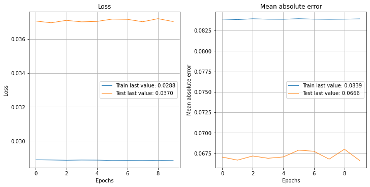

```python
fit_NN = model.fit(
            NN_train_features,
            NN_train_labels,
            batch_size=256,
            epochs = 10,
            validation_data=(NN_test_features,NN_test_labels),
            verbose = True
)
show_history(fit_NN)                                           # Plot, evidently!
```

批量大小的选择较为灵活。出于 GPU 训练效率等技术原因，通常取 2 的幂。

下图用度量指标展示同一过程。损失与度量指标两组曲线的绝对相关性通常很高；若其中一组趋于平坦，另一组往往也会如此。

可以调用 get_weights(model) 获取模型参数。18 这里不执行该代码，因为网络包含数千个权重，输出过于庞大。

实际预测通过常用的 predict() 函数生成。下面在测试集上调用该函数，并据此计算命中率。

```python
hitratio = np.mean(model.predict(NN_test_features) * NN_test_labels > 0)
print(f'Hit Ratio: {hitratio}')
```

```
Hit Ratio: 0.5416737440003773
```

命中率仍介于 50% 至 55%，看起来尚可。神经网络权重通常随机初始化，因此即使架构与训练数据完全相同，两次独立训练也可能产生差异很大的预测和表现。固定随机数生成器可以提高可复现性；也可以通过 set_weights() 函数加载权重，在模型之间复用参数。

### 7.4.2 分类示例

下面通过一个更详细的例子继续探索神经网络，目标是对二元标签 R1M_Usd_C 进行分类。开始前要先正确格式化标签，这里采用独热编码，参见第 4.5.2 节。

```python
from tensorflow.keras.utils import to_categorical

NN_train_labels_C = to_categorical(training_sample['R1M_Usd_C'].values) # One-hot encoding of the label
NN_test_labels_C = to_categorical(testing_sample['R1M_Usd_C'].values) # One-hot encoding of the label
```

标签 NN_train_labels_C 和 NN_test_labels_C 各有两列：第一列标记收益率高于中位数的样本，第二列标记收益率低于中位数的样本。特征变量无需修改，仍保持不变。下面构建的网络在第一个网络基础上增加了许多功能。

```python
from tensorflow.keras import initializers
from tensorflow.keras.constraints import non_neg

# Usage in a Keras layer:
initializer =initializers.RandomNormal()

model_C = keras.Sequential() # This defines the structure of the network, i.e. how layers are organized
model_C.add(layers.Dense(16, activation="tanh",           # Nb units & activation
                       input_shape=(len(features),),    # Size of input
                       kernel_initializer=initializer,  # Initialization of weights
                       kernel_constraint = non_neg()))   # Weights should be nonneg
model_C.add(layers.Dropout(.25))                          # Dropping out 25% units
model_C.add(layers.Dense(8, activation="elu",             # Nb units & activation
                       bias_initializer = initializers.Constant(0.2), # Initialization of biases
                       kernel_regularizer='l2'))        # Penalization of weights
model_C.add(layers.Dense(2,activation='softmax'))         # Softmax for categorical output
```

在解释各项设置前，需要强调：与许多 R 变量不同，Keras 模型是可变对象。这意味着调用模型后接入管道 %>% 的任何操作都会直接修改该模型。因此，连续多次训练并非每次从头开始，而是以上一次训练结果为起点。

首先说明，上下文中的设置只是为了展示功能，并非专门为提高模型表现而选择。相较第 7.4.1 节，第一项变化是激活函数。前两层只是换用了新的激活函数，输出层使用 softmax 则是分类任务所必需的：输出维度必须等于标签类别数，而 softmax 能生成相应的多维概率向量。因此，还要在输出层明确指定类别数。

第二类新增设置与参数有关，其中一组用于初始化权重和偏置。Keras 将权重称为“内核”（kernel）。初始化器种类很多，详见 https://keras.io/initializers/；大多数采用随机初始化，也有一些使用常数。

另一组设置是在训练期间对权重和偏置施加约束或范数惩罚。上例要求第一层权重非负，并以因子 (0.01) 乘以 $L^2$ 范数，惩罚第二层权重的幅度。

最后一项新增设置，是在第一层与第二层之间加入 Dropout 层，参见第 7.3.3 节。训练期间，第一层四分之一的单元会被随机停用。

具体训练设置如下。

```python
model_C.compile(   # Model specification
        optimizer=keras.optimizers.Adam(
                learning_rate=0.01,  # Optimisation method (weight updating)
                beta_1 = 0.9, # The exponential decay rate for the 1st moment estimates
                beta_2 = 0.95), # The exponential decay rate for the 2nd moment estimates
              loss=keras.losses.BinaryCrossentropy(from_logits=True),   # Loss function
              metrics=['categorical_accuracy'])  # Output metric
model_C.summary() # Model structure
```

```
Model: "sequential_2"
_________________________________________________________________
 Layer (type)                Output Shape              Param #
=================================================================
 dense_6 (Dense)             (None, 16)                1504

 dropout (Dropout)           (None, 16)                0

 dense_7 (Dense)             (None, 8)                 136

 dense_8 (Dense)             (None, 2)                 18

=================================================================
Total params: 1,658
Trainable params: 1,658
Non-trainable params: 0
_________________________________________________________________
```

这里的训练设置也有多处变化。代码使用 binary_crossentropy；它通常与单个 sigmoid 输出搭配处理二分类。本例采用两个 softmax 输出和独热标签，也可以更常规地使用 categorical_crossentropy；后者适用于两个及以上互斥类别。优化器也已更换，并包含多个参数，详见 Kingma 和 Ba（2014）。简单来说，两个 β 参数控制权重更新中指数加权移动平均的衰减率，这两个移动平均分别估计梯度的一阶矩和二阶矩，可用于调整各参数的更新步长。代码中的表现指标是分类准确率。多类别分类时，每个样本的预测是一个类别概率向量，最终类别取最大分量对应的类别；准确率就是预测类别与真实类别一致的样本比例。

最后开始训练模型。

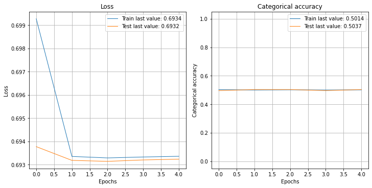

```python
callback = tf.keras.callbacks.EarlyStopping(monitor = "val_loss",    # Early stopping:
                                min_delta = 0.001,       # Improvement threshold
                                patience = 4,            # Nb epochs with no improvmt
                                verbose = 0 )            # No warnings

fit_NN_C = model_C.fit(
            NN_train_features, # Training features
            NN_train_labels_C, # Training labels
            batch_size=512, # Training parameters
            epochs = 20,  # Training parameters
            validation_data=(NN_test_features,NN_test_labels_C), # Test data
            verbose = True, # No comments from algo
            callbacks=[callback] # see callback above
            )
show_history(fit_NN_C)
```

图 7.8：采用提前停止的神经网络训练结果（分类任务）。

与前一次训练调用相比，这里只有一项主要区别。Keras 中的回调函数可以在训练过程的特定阶段执行操作；上例使用回调，在模型一段时间没有改善时停止训练。

数据集很大时，训练可能十分耗时，尤其是在批量较小或 epoch 较多的情况下。完整跑完预设 epoch 未必有用，因为损失或度量指标可能早已进入平台期。因此，若在指定时段内没有改善，就提前结束训练会更高效。这里把 epoch 数设为 20，但训练可能更早停止。

### 7.4.3 自定义损失

Keras 允许用户自定义损失函数，这在某些场景中很有用。例如，平方误差包含三项：  
$y_i^2$、$\tilde{y}_i^2$ 和 $-2y_i\tilde{y}_i$。实践中可以提高最后一项的重要性，因为我们尤其希望预测值与已实现值符号相同。下面展示如何在 Keras 中优化一个简单的乘积型函数 $l(y_i,\tilde{y}_i)=(\tilde{y}_i-\tilde{m})^2-\gamma (y_i-m)(\tilde{y}_i-\tilde{m})$，其中  
$m$ 和 $\tilde{m}$ 分别表示已实现值与预测值的样本均值；也就是说，后者 $\tilde{m}$ 是预测值 $\tilde{y}_i$ 的样本均值。当 $\gamma>2$ 时，交叉项获得更高权重。先从一个简单架构开始。

```python
model_custom = keras.Sequential() # this defines the structure of the network, i.e. how layers are organised
model_custom.add(layers.Dense(16, activation="relu", input_shape=(len(features),)))
model_custom.add(layers.Dense(8, activation="sigmoid"))
model_custom.add(layers.Dense(1)) # No activation means linear activation: f(x) = x
```

接着编写损失函数并把它接入模型。关键是使用软件包提供的专用函数 k_functions。这里实现的是预测值方差减去已实现值与预测值之间的缩放协方差，下面把缩放系数设为 5。

```python
def custom_loss(y_true, y_pred): # Defines the loss, we use gamma = 5
  loss = tf.reduce_mean(tf.square(y_pred - tf.reduce_mean(y_pred))) - 5 * tf.reduce_mean(
          (y_true - tf.reduce_mean(y_true))*(y_pred - tf.reduce_mean(y_pred)))
  return loss
model_custom.compile( # Model specification
              optimizer='RMSprop',  # Optim method
              loss=custom_loss, # New loss function
              metrics=['MeanAbsoluteError'])
```

至此可以训练模型，并简要评估其表现。

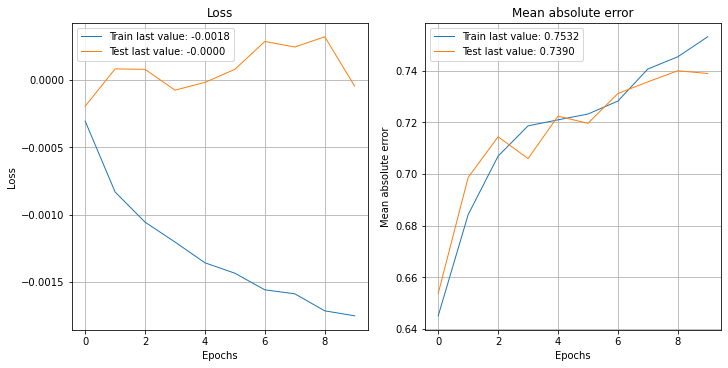

```python
fit_NN_cust = model_custom.fit(
            NN_train_features, # training features
            NN_train_labels, # Training labels
            batch_size=512, epochs = 10, # Training parameters
            validation_data=(NN_test_features,NN_test_labels), # Test data
            verbose = False) # No warnings
show_history(fit_NN_cust)
```

[figure not shown]

```python
hitratio = np.mean(model_custom.predict(NN_test_features) * NN_test_labels > 0) # Hit ratio
print(f'Hit Ratio: {hitratio}')
```

```
Hit Ratio: 0.44688639471285324
```

结果仍有改进空间，可以从多个方向着手。其中一个方向，是把静态模型改为动态模型，参见第 12 章。

## 7.5 循环网络

### 7.5.1 基本原理

多层感知机属于前馈网络，因为数据从左向右传递，中间没有循环连接。但在时间序列、语音识别等具有自然顺序的任务中，保留前一个样本的信息往往很有用。为这种“记忆”建模的一种简单方法，是使用下面这个只有一个隐藏层的网络：

\begin{align*} \tilde{y}_i&=f^{(y)}\left(\sum_{j=1}^{U_1}h_{i,j}w^{(y)}_j+b^{(2)}\right) \\ \textbf{h}_{i} &=f^{(h)}\left(\sum_{k=1}^{U_0}x_{i,k}w^{(h,1)}_k+b^{(1)}+ \underbrace{\sum_{k=1}^{U_1} w^{(h,2)}_{k}h_{i-1,k}}_{\text{memory part}} \right), \end{align*}

其中，向量 $h_0$ 通常初始化为零。

这类模型通常称为 Elman（1990）模型；若在计算 $h_i$ 时将 $h_{i-1}$ 替换为 $y_{i-1}$，则称为 Jordan（1997）模型。两者都属于循环神经网络（RNN）。

$h_i$ 通常称为状态或隐藏状态。训练这种模型较为复杂，需要沿全部样本把循环网络在时间维度展开，转化为一个很深的前馈网络，再按常规方式训练。图 7.9 展示了展开原理。第一个输入不仅影响第一步，还通过 $h_1$ 影响第二步及此后的所有步骤；类似地，第二个输入影响除第一步外的所有后续步骤。一般而言，样本 $i-1$ 会影响输出 $\tilde{y}_i$，以及所有满足 $j \ge i$ 的输出 $\tilde{y}_j$。图中蓝色标出需要训练的参数；同一组参数在展开网络的每个时间步都会重复出现。

[figure not shown]

图 7.9：循环网络的时间展开。

上述架构的主要问题，是**梯度消失**导致长期记忆衰减。模型在时间上展开后很深，反向传播的链式法则需要连乘大量激活函数导数。如图 7.4 所示，这些平滑函数的导数绝对值通常小于 1；许多小于 1 的数连续相乘后会迅速接近零。于是，梯度传到较早时间步时已经太小，参数几乎无法更新。

Hochreiter 和 Schmidhuber（1997）提出长短期记忆（LSTM）模型，用来防止记忆随时间逐步衰减。Chung 等人（2015）随后将其简化，得到下面介绍的门控循环单元（GRU）。GRU 比前述基础循环网络稍复杂，可表示为：

\begin{align*} \tilde{y}_i&=z_i\tilde{y}_{i-1}+ (1-z_i)\tanh \left(\textbf{w}_y'\textbf{x}_i+ b_y+ u_yr_i\tilde{y}_{i-1}\right) \quad \text{output (prediction)} \\ z_i &= \text{sig}(\textbf{w}_z'\textbf{x}_i+b_z+u_z\tilde{y}_{i-1}) \hspace{9mm} \text{`update gate'} \ \in (0,1)\\ r_i &= \text{sig}(\textbf{w}_r'\textbf{x}_i+b_r+u_r\tilde{y}_{i-1}) \hspace{9mm} \text{`reset gate'} \ \in (0,1). \end{align*}

写成紧凑形式即为

\begin{equation} \tilde{y}_i=\underbrace{z_i}_{\text{weight}}\underbrace{\tilde{y}_{i-1}}_{\text{past value}}+ \underbrace{(1-z_i)}_{\text{weight}}\underbrace{\tanh \left(\textbf{w}_y'\textbf{x}_i+ b_y+ u_yr_i\tilde{y}_{i-1}\right)}_{\text{candidate value (classical RNN)}}, \end{equation}

其中，$z_i$ 决定过去状态与当前候选值如何组合；$r_i$ 则决定计算候选值时保留多少历史信息。$r_i$ 称为“重置门”，$z_i$ 称为“更新门”。

循环网络的训练有若干细节需要注意。由于样本之间存在时序连接，每个批次都必须对应一段连贯的时间序列。因此，一种自然做法是按资产组织批次，并让各资产内部的样本按时间排序。某些框架还支持在批次之间保留状态：把上一批次最后的 $\tilde{y}_i$ 传给下一批次，作为其 $\tilde{y}_0$。这称为有状态模式，使用时必须谨慎。若每个批次包含某项资产的全部观测，就不应把上一项资产的状态传给下一项资产，因为不同资产之间没有这种直接时序联系。只有当同一资产的数据被分成多个连续批次时，跨批次保留状态才可能合理，但训练仍需仔细设计。

循环网络，尤其是 LSTM，已被证明在一些金融场景中具有良好预测能力，例如参见 Fischer 和 Krauss（2018）以及 Wang 等人（2020）。

### 7.5.2 代码与结果

循环网络在理论上比多层感知机更复杂，实现起来也更具挑战。与前馈架构相比，其序列连接需要格外处理。在资产定价中，必须把不同资产的时间序列分开，不能把各只股票的序列首尾相接；训练应按资产逐一组织。

变量维度至关重要。Keras 中 RNN 的输入维度依次为：

1. 批量大小：本例中等于资产数，每项资产对应一条独立序列；
2. 时间步数：本例中等于日期数；
3. 特征数：即预测变量数。

为简化处理并减少计算时间，这里使用与第 5.2.2 节相同的股票子集，从而得到完整的矩形面板：每个日期都包含相同数量的观测。

首先创建若干中间变量。

```python
data_rnn = data_ml[data_ml['stock_id'].isin(stock_ids_short)] # Dedicated dataset
training_sample_rnn = data_rnn[data_rnn['date'] < separation_date] # Training set
testing_sample_rnn = data_rnn[data_rnn['date'] > separation_date] # Test set

nb_stocks = len(stock_ids_short) # Nb stocks
nb_feats = len(features) # Nb features
nb_dates_train = training_sample_rnn.shape[0] // nb_stocks # Nb training dates
nb_dates_test = testing_sample_rnn.shape[0] // nb_stocks # Nb testing dates

nn_train_features = training_sample_rnn[features].values # Train features in array format
nn_test_features = testing_sample_rnn[features].values # Test features in array format
nn_train_labels = training_sample_rnn['R1M_Usd'].values # Train label in array format
nn_test_labels = testing_sample_rnn['R1M_Usd'].values # Test label in array format
```

接着构造要传入模型的变量。数据文件先按股票、再按日期排序，参见第 1.2 节。

```python
train_features_rnn = np.reshape(nn_train_features, # Formats the training data into tricky ordered array
                                (nb_stocks, nb_dates_train, nb_feats)) # The order is: stock, date, feature
test_features_rnn = np.reshape(nn_test_features, # Formats the training data into tricky ordered array
                               (nb_stocks, nb_dates_test, nb_feats)) # The order is: stock, date, feature
train_labels_rnn = np.reshape(nn_train_labels, (nb_stocks, nb_dates_train, 1))
test_labels_rnn = np.reshape(nn_test_labels, (nb_stocks, nb_dates_test, 1))
```

最后进入训练阶段。为简单起见，只使用一个单层 RNN，其循环单元采用门控循环单元（GRU）。结构如下。

```python
model_RNN = keras.Sequential()
model_RNN.add(layers.GRU(16, # Nb units in hidden layer
                         batch_input_shape = (nb_stocks, nb_dates_train, nb_feats), # Dimensions = tricky part
                         activation='tanh', # Activation function
                         return_sequences=True)) # Return all the sequence
model_RNN.add(layers.Dense(1)) # Final aggregation layer
model_RNN.compile(optimizer='RMSprop', # Loss = quadratic
              loss='mse', # Backprop
              metrics=['MeanAbsoluteError']) # Output metric MAE
```

循环层提供许多设置选项。GRU 的详细说明见 Keras 文档 https://keras.rstudio.com/reference/layer_gru.html。这里特别启用 return_sequences。许多任务只返回序列的最后一个值，但本例的标签本身是一条完整序列；若不返回全部时间步的输出，预测与标签的维度就无法匹配。结构确定后即可开始训练。

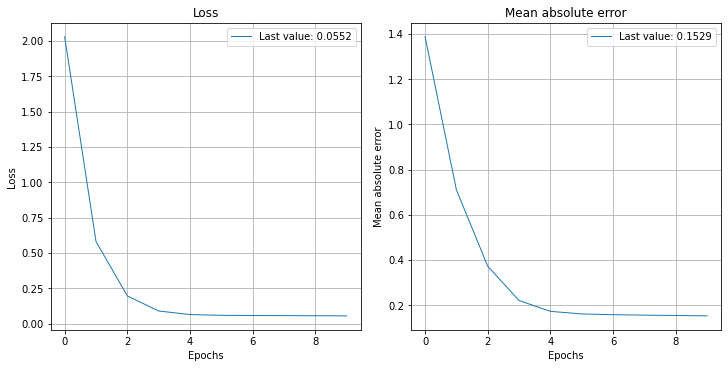

```python
fit_RNN = model_RNN.fit(train_features_rnn, # Training features
                        train_labels_rnn, # Training labels
                        epochs = 10, # Number of rounds
                        batch_size = nb_stocks, # Length of sequences
                        verbose=False) # No warnings
show_history(fit_RNN)
```

图 7.10：循环神经网络的训练结果（回归任务）。

与前面的模型相比，这里的输入代码和图 7.10 的输出都没有使用验证集或测试集。原因在于 Keras 对 RNN 的输入维度要求严格，训练样本与测试样本必须具有相同形状。本例显然不满足这一条件，因此需要复制模型并调整维度来解决。

```python
new_model = keras.Sequential()
new_model.add(layers.GRU(16,
                         batch_input_shape = (nb_stocks, nb_dates_test, nb_feats), # New dimensions
                         activation='tanh', # Activation function
                         return_sequences=True)) # Return the full sequence
new_model.add(layers.Dense(1)) # Output dimension
new_model.set_weights(model_RNN.get_weights())
```

新模型准备好且维度匹配后，就可以用 predict() 函数预测测试集，并立即计算命中率。

```python
pred_rnn = new_model.predict(test_features_rnn, batch_size = nb_stocks) # Predictions
hitratio = np.mean(np.multiply(pred_rnn,test_labels_rnn) > 0) # Hit ratio
print(f'Hit Ratio: {hitratio}')
```

```
Hit Ratio: 0.498276586801177
```

命中率接近 50%，说明该模型的表现几乎没有优于随机猜测。

结束 RNN 这一节之前，再介绍一种较新的架构——$α$-RNN。它比 LSTM 和 GRU 更简单：在普通 RNN 中加入简单的自相关结构，以形成长期记忆。更多细节请参阅 Matthew F Dixon (2020)。

## 7.6 其他常见架构

本节介绍其他几种网络结构。由于这些架构应用较少，而且通常更难实现，这里不提供代码示例，只介绍其基本原理。

### 7.6.1 生成对抗网络

生成对抗网络（GAN）的基本思路，是让一个网络不断尝试欺骗另一个网络，从而提高后者的辨别能力。这一广为流传的方法由 Goodfellow 等人（2014）提出。假设你是毕加索画作的鉴定专家，自信能够轻松认出他的任何作品。检验并磨炼这种能力的一种方法，就是让你与造假者交手：真正的专家应当能够区分毕加索真迹与赝品。GAN 的原理正是如此。

GAN 由两个神经网络组成：第一个网络学习辨别真假，第二个网络则试图欺骗第一个网络，使其判断出错。与上面的例子一样，这里也有两组数据：一组 ($\textbf{x}$) 是来自常规训练样本的真实数据，另一组 ($\textbf{x}$) 是由造假网络生成的虚假数据。

在 GAN 的术语中，负责学习辨别的网络记为 $D$，即判别器；负责生成虚假数据的网络记为 $G$，即生成器。GAN 最初用于分类，这里也沿用这一设定以便说明。判别器输出一个标量，表示其输入来自真实数据而非虚假数据的概率。$G$ 的输入是任意噪声，输出则与 $D$ 的输入具有相同的形状和形式。

下面直接给出 GAN 的理论目标函数，再作解释。$D$ 与 $G$ 进行如下极小极大博弈：

\begin{equation} \tag{7.7} \underset{G}{\min} \ \underset{D}{\max} \ \left\{ \mathbb{E}[\log(D(\textbf{x}))]+\mathbb{E}[\log(1-D(G(\textbf{z})))] \right\}. \end{equation}

先从两个优化方向来理解这个表达式。第一部分是对判别器的最大化，这是一个常规分类目标：算法希望尽可能提高为所有样本分配正确标签的概率。与经济学和金融学中的做法类似，程序最大化的不是 $D(\textbf{x})$ 本身的平均值，而是它的某种函数形式，这里采用对数函数，作用类似于效用函数。

左侧的期望针对真实数据 $\textbf{x}$ 计算，因此目标应随判别器输出增大而提高。右侧的期望针对虚假样本计算，正确判断意味着把它识别为假，因此对应 $1-D(G(\textbf{z}))$。

第二个优化方向是对生成器的最小化：生成器试图降低判别器在模拟数据上的辨别能力，也就是让 $D$ 更难发现数据是伪造的。式（7.8）概括了这一网络结构。

\begin{equation} \tag{7.8} \left. \begin{array}{rlll} \text{training sample} = \textbf{x} = \text{true data} && \\ \text{noise}= \textbf{z} \quad \overset{G}{\rightarrow} \quad \text{fake data} & \end{array} \right\} \overset{D}{\rightarrow} \text{output = probability for label} \end{equation}

在基于机器学习的资产定价研究中，Luyang Chen、Pelger 和 Zhu（2020）提出了 GAN 最具代表性的应用之一。他们利用如下矩条件：

\begin{equation} \mathbb{E}[M_{t+1}r_{t+1,n}g(I_t,I_{t,n})]=0, \end{equation}

这是式（3.7）的一个应用。其中，工具变量 $I_{t,n}$ 与公司有关，例如公司特征和属性；$I_t$ 则表示宏观经济变量，例如市场整体股息率、波动率水平、信用利差和期限利差等。函数 $g$ 输出 $d$ 维向量，因此上式给出 $d$ 个矩条件。关键做法是把随机贴现因子（SDF）建模为未知的资产组合 $M_{t+1}=1-\sum_{n=1}^Nw(I_t,I_{t,n})r_{t+1,n}$。主判别网络 ($D$) 通过权重 $w(I_t,I_{t,n})$ 来近似 SDF；第二个生成网络则通过上式中的 $g(I_t,I_{t,n})$ 构造矩条件。

该网络的完整设定如下：

\begin{equation} \underset{w}{\text{min}} \ \underset{g}{\text{max}} \ \sum_{j=1}^N \left\| \mathbb{E} \left[\left(1-\sum_{n=1}^Nw(I_t,I_{t,n})r_{t+1,n} \right)r_{t+1,j}g(I_t,I_{t,j})\right] \right\|^2, \end{equation}

其中，$L^2$ 范数作用于 $g$ 生成的 $d$ 个输出。这里并不要求资产定价矩条件严格等于零，而是让模型尽可能逼近这一关系。由 $\textbf{w}$ 定义的网络负责建立资产定价模型，寻找尽可能好的模型；由 $\textbf{g}$ 定义的网络则寻找令模型表现最差的条件。两个网络的完整设定请参阅原文。Luyang Chen、Pelger 和 Zhu（2020）的实证结果表明，与 Gu、Kelly 和 Xiu（2020b）所采用的纯预测式“普通”方法相比，引入资产定价约束能够提升模型价值。按照模型预测值划分的十分位投资组合，在样本外也呈现随十分位次序单调变化的表现。

GAN 还可用于生成人工金融数据（参见 Efimov 和 Xu (2019)、Marti (2019)、Wiese 等人 (2020)、Ni 等人 (2020)，以及相关的 Buehler 等人 (2020)），但这一主题超出了本书的范围。

### 7.6.2 自编码器

近年来，自编码器 (AE) 已用于 Huck (2019) 的投资组合管理研究，以及 Gu、Kelly 和 Xiu (2020a) 的资产定价研究。

自编码器（AE）是一类较为特殊的神经网络，因为它属于无监督算法。若借用监督学习的说法，它的标签就是输入本身。与 GAN 一样，自编码器也由两个网络组成，但结构截然不同：第一个网络把输入编码为某种中间表示，通常称为编码；第二个网络再把编码解码为输入的重构版本。

\begin{array}{ccccccccc} \textbf{x} & &\overset{E}{\longrightarrow} && \textbf{z} && \overset{D}{\longrightarrow} && \textbf{x}' \\ \text{input} && \text{encoder} && \text{code} && \text{decoder} && \text{modified input} \end{array}

由于自编码器不属于监督学习算法，本书将其详细介绍留到第 15.2.3 节。

Gu、Kelly 和 Xiu (2020a) 借鉴了 AE 的思路，同时提高了资产定价模型的复杂度。他们从简单设定 $r_t=\boldsymbol{\beta}_{t-1}\textbf{f}_t+e_t$ 出发（为简化符号，这里省略资产下标），进一步假设贝塔取决于公司特征，而因子本身可以是收益率的非线性函数。模型形式如下：

\begin{equation} \tag{7.9} r_{t,i}=\textbf{NN}_{\textbf{beta}}(\textbf{x}_{t-1,i})+\textbf{NN}_{\textbf{factor}}(\textbf{r}_t)+e_{t,i}, \end{equation}

其中，$\textbf{NN}_{\textbf{beta}}$ 和 $\textbf{NN}_{\textbf{factor}}$ 是两个神经网络。由于收益率同时充当输入和输出，上式具有自编码器的形式；额外的复杂性则来自第二个神经网络 $\textbf{NN}_{\textbf{beta}}$。Keras 等现代神经网络库允许构建这类自定义模型。该结构的实现留作下文练习。

### 7.6.3 卷积网络简述

得益于计算机视觉竞赛中的一系列成功，神经网络在 2010 年代迅速普及，推动这些进展的正是卷积神经网络（CNN）。CNN 用于金融预测乍看似乎出人意料，但计算机科学领域已有多个研究团队提出相关方法（J.-F. Chen 等人 (2016)、Loreggia 等人 (2016)、Dingli 和 Fournier (2017)、Tsantekidis 等人 (2017)、Hoseinzade 和 Haratizadeh (2019)）。最近，J. Jiang、Kelly 和 Xiu (2020) 提出从价格走势图片中提取信号。因此，本章最后简要介绍 CNN 的基本原理。这里以二维 CNN 为例，但 CNN 也可用于一维或三维数据。

CNN 的价值在于，它能在保留局部信息的同时，逐步降低大型数据集的维度。图像可以看作一个像素矩形，每个像素通常由三个通道编码，分别对应红、蓝、绿三种颜色。为简化说明，这里只考虑一个通道，例如一幅 1,000 x 1,000 像素的图像，每个像素只有一个数值。为了分析图像内容，卷积层通过卷积运算压缩输入维度。直观地说，就是用带有一组权重的矩形窗口在图像上滑动，对窗口覆盖的数值进行加权变换。

\begin{equation} o_{i,k}=\sum_{j=1}^J\sum_{l=1}^Lw_{j,l}x_{i+j-1,k+l-1}. \end{equation}

[figure not shown]

图 7.11：卷积单元示意图。注：图中标注的是一般维度，并不对应方格的实际数量。

若仅靠连续堆叠上述卷积层来逐步降低输出维度，计算成本会很高，而且大量权重还可能导致过拟合。为了更高效地缩小输出，通常会使用**池化层**。池化单元把一个局部矩阵归约为单个统计量，例如该矩阵的最小值、最大值或平均值：

\begin{equation} o_{i,k}=f(x_{i+j-1,k+l-1}, 1\le j\le J, 1 \le l\le L), \end{equation}

其中，$f$ 取最小值、最大值或平均值。图 7.12 给出了池化示例。为了加快压缩，还可以设置步幅来跳过部分单元格。步幅为 $v$ 时，每隔 $v$ 个位置才执行一次操作，从而略过中间位置。图 7.12 左侧两种情形未使用步幅，因此维度缩减量只取决于池化窗口的大小；右侧加入步幅后，压缩更为明显。对于 1,000 x 1,000 的输入，采用步幅为 2 的 2 x 2 池化层，将得到 500 x 500 的输出，即元素数量缩减为原来的四分之一，如图 7.12 右侧所示。

[figure not shown]

图 7.12：池化单元示意图。

借助这些工具，可以构建新的预测模型。Hoseinzade 和 Haratizadeh（2019）把价格报价、技术指标和宏观经济数据等预测变量输入一个复杂的 6 层神经网络，用来预测价格变动的方向。尽管这在计算机科学上很有意思，但选择这种架构的深层经济动机仍不明确。Sangadiev et al. (2020) 则使用 CNN，基于限价订单簿数据构建投资组合。

## 7.6.4 高级架构

神经网络在计算机视觉和自然语言处理任务中的优势已经得到充分验证。然而，在 2010 年代的许多机器学习竞赛中，面对表格数据时，神经网络往往不及基于树的模型。这一现象促使研究人员设计更适合表格数据的新型神经网络结构，例如 Arik 和 Pfister (2019) 以及 Popov、Morozov 和 Babenko (2019) 的方法，但其具体思路超出了本书范围。反过来的探索也同样存在：Nuti、Rugama 和 Thommen（2019）尝试调整树模型和随机森林，使其行为更接近神经网络。感兴趣的读者可参阅原文。

## 7.7 编程练习

本练习要求实现 Gu、Kelly 和 Xiu (2020a) 所述的自编码器模型（参见第 7.6.2 节）。实现神经网络时，必须严谨地标明各层维度。因此，图 7.13 再次给出模型结构，并清楚标示输入、输出及其维度。

[figure not shown]

图 7.13：自编码器资产定价模型示意图。

要充分发挥 Keras 的能力，需要采用更通用的神经网络构建方式，即函数式 API：https://keras.io/guides/functional_api/。

## 参考文献

Aldridge, Irene, and Marco Avellaneda. 2019. “Neural Networks in Finance: Design and Performance.” Journal of Financial Data Science 1 (4): 39–62.

Anderson, James A, and Edward Rosenfeld. 2000. Talking Nets: An Oral History of Neural Networks. MIT Press.

Arik, Sercan O, and Tomas Pfister. 2019. “TabNet: Attentive Interpretable Tabular Learning.” arXiv Preprint, no. 1908.07442.

Babiak, Mykola, and Jozef Barunik. 2020. “Deep Learning, Predictability, and Optimal Portfolio Returns.” arXiv Preprint, no. 2009.03394.

Bansal, Ravi, and Salim Viswanathan. 1993. “No Arbitrage and Arbitrage Pricing: A New Approach.” Journal of Finance 48 (4): 1231–62.

Barron, Andrew R. 1993. “Universal Approximation Bounds for Superpositions of a Sigmoidal Function.” IEEE Transactions on Information Theory 39 (3): 930–45.

Barron, Andrew R. 1994. “Approximation and Estimation Bounds for Artificial Neural Networks.” Machine Learning 14 (1): 115–33.

Bengio, Yoshua. 2012. “Practical Recommendations for Gradient-Based Training of Deep Architectures.” In Neural Networks: Tricks of the Trade, 437–78. Springer.

Buehler, Hans, Blanka Horvath, Terry Lyons, Imanol Perez Arribas, and Ben Wood. 2020. “Generating Financial Markets with Signatures.” SSRN Working Paper 3657366.

Burrell, Phillip R., and Bukola Otulayo Folarin. 1997. “The Impact of Neural Networks in Finance.” Neural Computing & Applications 6 (4): 193–200.

Chen, Jou-Fan, Wei-Lun Chen, Chun-Ping Huang, Szu-Hao Huang, and An-Pin Chen. 2016. “Financial Time-Series Data Analysis Using Deep Convolutional Neural Networks.” In 2016 7th International Conference on Cloud Computing and Big Data (Ccbd), 87–92. IEEE.

Chen, Luyang, Markus Pelger, and Jason Zhu. 2020. “Deep Learning in Asset Pricing.” SSRN Working Paper 3350138.

Chollet, François. 2017. Deep Learning with Python. Manning Publications Company.

Chung, Junyoung, Caglar Gulcehre, Kyunghyun Cho, and Yoshua Bengio. 2015. “Gated Feedback Recurrent Neural Networks.” In International Conference on Machine Learning, 2067–75.

Costarelli, Danilo, Renato Spigler, and Gianluca Vinti. 2016. “A Survey on Approximation by Means of Neural Network Operators.” Journal of NeuroTechnology 1 (1).

Cybenko, George. 1989. “Approximation by Superpositions of a Sigmoidal Function.” Mathematics of Control, Signals and Systems 2 (4): 303–14.

Dingli, Alexiei, and Karl Sant Fournier. 2017. “Financial Time Series Forecasting–a Deep Learning Approach.” International Journal of Machine Learning and Computing 7 (5): 118–22.

Dixon, Matthew F. 2020. “Industrial Forecasting with Exponentially Smoothed Recurrent Neural Networks.” SSRN Working Paper, no. 3572181.

Du, Ke-Lin, and Madisetti NS Swamy. 2013. Neural Networks and Statistical Learning. Springer Science & Business Media.

Duchi, John, Elad Hazan, and Yoram Singer. 2011. “Adaptive Subgradient Methods for Online Learning and Stochastic Optimization.” Journal of Machine Learning Research 12 (Jul): 2121–59.

Eakins, Stanley G, Stanley R Stansell, and James F Buck. 1998. “Analyzing the Nature of Institutional Demand for Common Stocks.” Quarterly Journal of Business and Economics, 33–48.

Efimov, Dmitry, and Di Xu. 2019. “Using Generative Adversarial Networks to Synthesize Artificial Financial Datasets.” Proceedings of the Conference on Neural Information Processing Systems.

Elman, Jeffrey L. 1990. “Finding Structure in Time.” Cognitive Science 14 (2): 179–211.

Enke, David, and Suraphan Thawornwong. 2005. “The Use of Data Mining and Neural Networks for Forecasting Stock Market Returns.” Expert Systems with Applications 29 (4): 927–40.

Feng, Guanhao, Nicholas G Polson, and Jianeng Xu. 2019. “Deep Learning in Characteristics-Sorted Factor Models.” SSRN Working Paper 3243683.

Fischer, Thomas, and Christopher Krauss. 2018. “Deep Learning with Long Short-Term Memory Networks for Financial Market Predictions.” European Journal of Operational Research 270 (2): 654–69.

Goodfellow, Ian, Yoshua Bengio, Aaron Courville, and Yoshua Bengio. 2016. Deep Learning. MIT Press Cambridge.

Goodfellow, Ian, Jean Pouget-Abadie, Mehdi Mirza, Bing Xu, David Warde-Farley, Sherjil Ozair, Aaron Courville, and Yoshua Bengio. 2014. “Generative Adversarial Nets.” In Advances in Neural Information Processing Systems, 2672–80.

Gu, Shihao, Bryan T Kelly, and Dacheng Xiu. 2020a. “Autoencoder Asset Pricing Models.” Journal of Econometrics Forthcoming.

Gu, Shihao, Bryan T Kelly, and Dacheng Xiu. 2020b. “Empirical Asset Pricing via Machine Learning.” Review of Financial Studies 33 (5): 2223–73.

Guliyev, Namig J, and Vugar E Ismailov. 2018. “On the Approximation by Single Hidden Layer Feedforward Neural Networks with Fixed Weights.” Neural Networks 98: 296–304.

Guresen, Erkam, Gulgun Kayakutlu, and Tugrul U Daim. 2011. “Using Artificial Neural Network Models in Stock Market Index Prediction.” Expert Systems with Applications 38 (8): 10389–97.

Hanin, Boris, and David Rolnick. 2018. “How to Start Training: The Effect of Initialization and Architecture.” In Advances in Neural Information Processing Systems, 571–81.

Haykin, Simon S. 2009. Neural Networks and Learning Machines. Prentice Hall.

Hochreiter, Sepp, and Jürgen Schmidhuber. 1997. “Long Short-Term Memory.” Neural Computation 9 (8): 1735–80.

Hoseinzade, Ehsan, and Saman Haratizadeh. 2019. “CNNpred: CNN-Based Stock Market Prediction Using a Diverse Set of Variables.” Expert Systems with Applications 129: 273–85.

Huck, Nicolas. 2019. “Large Data Sets and Machine Learning: Applications to Statistical Arbitrage.” European Journal of Operational Research 278 (1): 330–42.

Jiang, Weiwei. 2020. “Applications of Deep Learning in Stock Market Prediction: Recent Progress.” arXiv Preprint, no. 2003.01859.

Jordan, Michael I. 1997. “Serial Order: A Parallel Distributed Processing Approach.” In Advances in Psychology, 121:471–95.

Kimoto, Takashi, Kazuo Asakawa, Morio Yoda, and Masakazu Takeoka. 1990. “Stock Market Prediction System with Modular Neural Networks.” In 1990 Ijcnn International Joint Conference on Neural Networks, 1–6. IEEE.

Kingma, Diederik P, and Jimmy Ba. 2014. “Adam: A Method for Stochastic Optimization.” arXiv Preprint, no. 1412.6980.

Krauss, Christopher, Xuan Anh Do, and Nicolas Huck. 2017. “Deep Neural Networks, Gradient-Boosted Trees, Random Forests: Statistical Arbitrage on the S&P 500.” European Journal of Operational Research 259 (2): 689–702.

Lee, Sang Il. 2020. “Hyperparameter Optimization for Forecasting Stock Returns.” arXiv Preprint, no. 2001.10278.

Lim, Bryan, and Stefan Zohren. 2020. “Time Series Forecasting with Deep Learning: A Survey.” arXiv Preprint, no. 2004.13408.

Loreggia, Andrea, Yuri Malitsky, Horst Samulowitz, and Vijay Saraswat. 2016. “Deep Learning for Algorithm Portfolios.” In Proceedings of the Thirtieth Aaai Conference on Artificial Intelligence, 1280–6. AAAI Press.

Ma, Yilin, Ruizhu Han, and Weizhong Wang. 2020. “Portfolio Optimization with Return Prediction Using Deep Learning and Machine Learning.” Expert Systems with Applications Forthcoming: 113973.

Marti, Gautier. 2019. “CorrGAN: Sampling Realistic Financial Correlation Matrices Using Generative Adversarial Networks.” arXiv Preprint, no. 1910.09504.

Masters, Timothy. 1993. Practical Neural Network Recipes in C++. Morgan Kaufmann.

Nesterov, Yurii. 1983. “A Method for Unconstrained Convex Minimization Problem with the Rate of Convergence O (1/K^ 2).” In Doklady an Ussr, 269:543–47.

Ni, Hao, Lukasz Szpruch, Magnus Wiese, Shujian Liao, and Baoren Xiao. 2020. “Conditional Sig-Wasserstein GANs for Time Series Generation.” arXiv Preprint, no. 2006.05421.

Nuti, Giuseppe, Lluı́s Antoni Jiménez Rugama, and Kaspar Thommen. 2019. “Adaptive Reticulum.” arXiv Preprint, no. 1912.05901.

Olazaran, Mikel. 1996. “A Sociological Study of the Official History of the Perceptrons Controversy.” Social Studies of Science 26 (3): 611–59.

Orimoloye, Larry Olanrewaju, Ming-Chien Sung, Tiejun Ma, and Johnnie EV Johnson. 2019. “Comparing the Effectiveness of Deep Feedforward Neural Networks and Shallow Architectures for Predicting Stock Price Indices.” Expert Systems with Applications, 112828.

Polyak, Boris T. 1964. “Some Methods of Speeding up the Convergence of Iteration Methods.” USSR Computational Mathematics and Mathematical Physics 4 (5): 1–17.

Popov, Sergei, Stanislav Morozov, and Artem Babenko. 2019. “Neural Oblivious Decision Ensembles for Deep Learning on Tabular Data.” arXiv Preprint, no. 1909.06312.

Rosenblatt, Frank. 1958. “The Perceptron: A Probabilistic Model for Information Storage and Organization in the Brain.” Psychological Review 65 (6): 386.

Sangadiev, Aiusha, Rodrigo Rivera-Castro, Kirill Stepanov, Andrey Poddubny, Kirill Bubenchikov, Nikita Bekezin, Polina Pilyugina, and Evgeny Burnaev. 2020. “DeepFolio: Convolutional Neural Networks for Portfolios with Limit Order Book Data.” arXiv Preprint, no. 2008.12152.

Sezer, Omer Berat, Mehmet Ugur Gudelek, and Ahmet Murat Ozbayoglu. 2019. “Financial Time Series Forecasting with Deep Learning: A Systematic Literature Review: 2005-2019.” arXiv Preprint, no. 1911.13288.

Smith, Leslie N. 2018. “A Disciplined Approach to Neural Network Hyper-Parameters: Part 1–Learning Rate, Batch Size, Momentum, and Weight Decay.” arXiv Preprint, no. 1803.09820.

Soleymani, Farzan, and Eric Paquet. 2020. “Financial Portfolio Optimization with Online Deep Reinforcement Learning and Restricted Stacked Autoencoder-Deepbreath.” Expert Systems with Applications Forthcoming: 113456.

Srivastava, Nitish, Geoffrey Hinton, Alex Krizhevsky, Ilya Sutskever, and Ruslan Salakhutdinov. 2014. “Dropout: A Simple Way to Prevent Neural Networks from Overfitting.” Journal of Machine Learning Research 15 (1): 1929–58.

Tsantekidis, Avraam, Nikolaos Passalis, Anastasios Tefas, Juho Kanniainen, Moncef Gabbouj, and Alexandros Iosifidis. 2017. “Forecasting Stock Prices from the Limit Order Book Using Convolutional Neural Networks.” In 2017 Ieee 19th Conference on Business Informatics (Cbi), 1:7–12.

Wang, Wuyu, Weizi Li, Ning Zhang, and Kecheng Liu. 2020. “Portfolio Formation with Preselection Using Deep Learning from Long-Term Financial Data.” Expert Systems with Applications 143: 113042.

Wiese, Magnus, Robert Knobloch, Ralf Korn, and Peter Kretschmer. 2020. “Quant Gans: Deep Generation of Financial Time Series.” Quantitative Finance Forthcoming.

Zeiler, Matthew D. 2012. “ADADELTA: An Adaptive Learning Rate Method.” arXiv Preprint, no. 1212.5701.

Zhang, Yudong, and Lenan Wu. 2009. “Stock Market Prediction of S&P 500 via Combination of Improved Bco Approach and Bp Neural Network.” Expert Systems with Applications 36 (5): 8849–54.

脚注

1. 近年来，神经网络也被用于衍生品定价与对冲，例如 Buehler 等人 (2019)、Andersson 和 Oosterlee (2020) 的研究，以及 Ruf 和 Wang (2019) 的综述。Wu 等人（2020）发现，深度学习能够有效筛选表现良好的对冲基金。限价订单簿建模同样是神经网络应用不断扩展的领域（Sirignano 和 Cont (2019)、Wallbridge (2020)）。↩︎
2. 如果出现软件包冲突，请使用 keras::get_weights(model)。机器学习领域的另一个软件包 yardstick 也使用函数名“get_weights”。↩︎